# BIO00066I Cell Biology: Workshop 2

### Density plots

A density plot might be be better. So let’s try that.

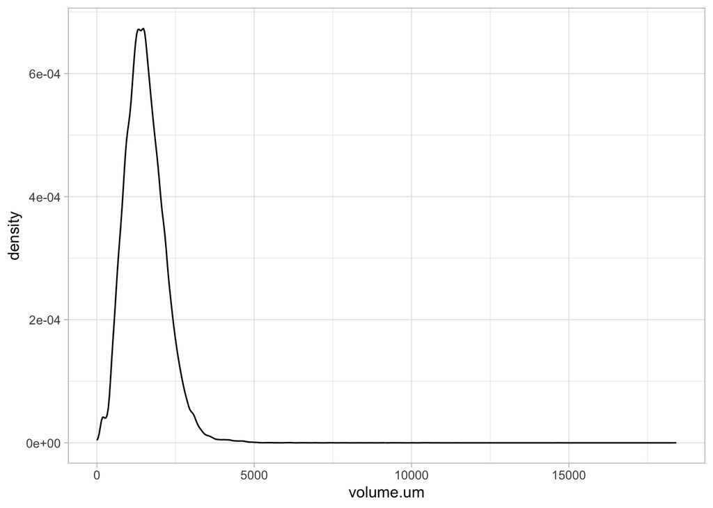

```r
ggplot(cells, aes(x=volume.um))+
  geom_density()+
  theme_light()
```

Now examine the **radius** using a **density plot**.

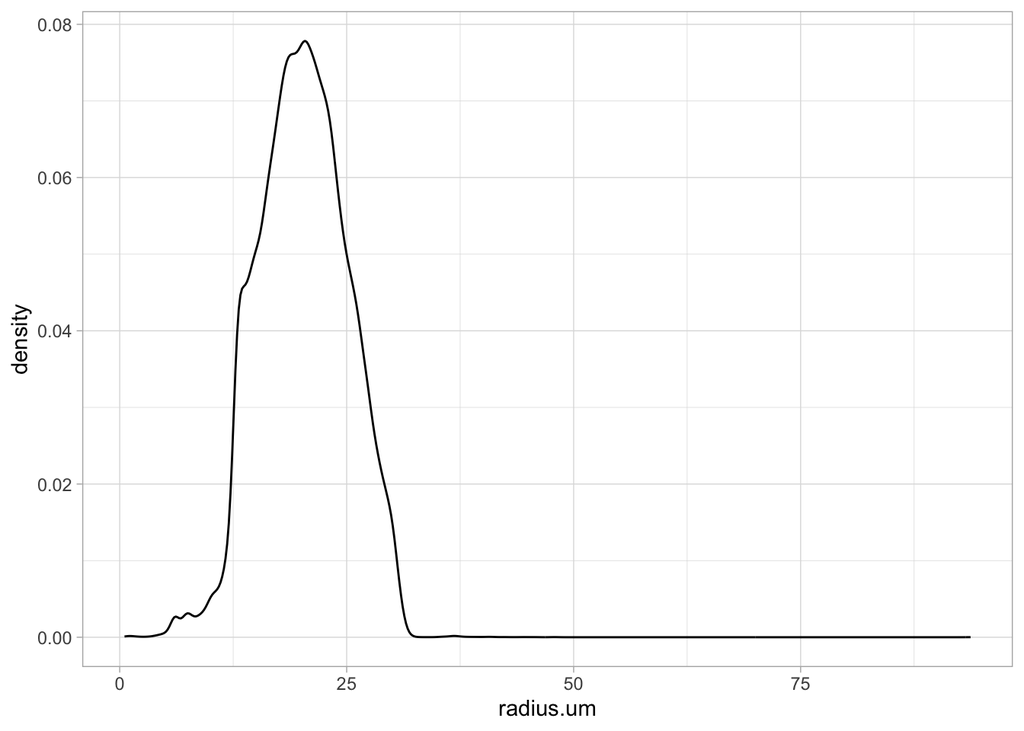

```r
ggplot(cells, aes(x=radius.um))+
  geom_density()+
  theme_light()
```

Looks like there might be **two populations** here, perhaps?

### Arranging many plots together

Sometimes we want more than one plot on a page. The simple way to do this is to use **ggarrange**.

```r
#volumne
volume.plot<-ggplot(cells, aes(x=width.um))+
  geom_density()+
  theme_light()
```

Now make another plot, and save this plot as an object with another sensible name. Sensible clear object names are another element of data hygiene.

```r
#radius
radius.plot<-ggplot(cells, aes(x=radius.um))+
  geom_density()+
  theme_light()
```

Now we can arrange these plots onto one page.

- **ncol** specifies the number of columns the ‘plot grid’ has
- **nrow** specifies the number of rows the ‘plot grid’ has

```r
density.plots<-ggarrange(
  volume.plot,
  radius.plot,
  ncol = 2,
  nrow = 1
)
```

Now save the plot as a jpeg. The default width and height = 7, so lets make it wider.

```r
#plot filename
ggsave(density.plots,
  file="plots/volume-and-radius.density.plots.jpeg",
  width = 7*2,
  height = 7
)
```

## Final comments

**Keep this file somewhere safe, or email it to yourself.**

PS: It may feel like we didn’t do very much biology today. But because we created a simple tidy object all our data analysis will be much easier from now on.